# Notebook

**Research Question:** "Judgement ⑪ scored coded values at ~28% agreement by Jaccard set-overlap. How much of that was a *measurement artifact* (right value, different phrasing) versus a genuine coding error — and which fields are which?"

*A re-score of ⑪ using an Opus semantic-equivalence judge on the same codings. This decides whether the fix is normalization (a formatting problem) or something deeper.*

**Abstract.** ⑪'s ~28% value agreement was measured by Jaccard set-overlap, which scores "2" vs "at least 2" as a total miss. Re-scoring the exact same codings with an **Opus semantic-equivalence judge** — across **22 models**, **4,237 co-populated field-values** — splits that number into a good-news story and a real caveat. **Good news:** by Jaccard the mean is **29%**, but semantically **62%** of values are *equivalent* to gold and **82%** are equivalent-or-a-correct-subset — so the scalar-field panic (age/dose/counts/dates that scored 0 on Jaccard for saying "2" instead of "at least 2") was a pure **measurement artifact**. The fields that jump most (clinical_trial_participation, family_history, hormonal_events, vaccination_status) are fixed by normalization alone. **The caveat:** ~18% of values are *genuinely* wrong (Verdict mix: 62% equivalent, 20% correct-but-less-complete, 18% different), and that error is **not uniform** — it concentrates in interpretive free-text fields (healthcare_system 47%, alternative_treatments 34%, functional_status_tier 30%, conditions 30%, social_impact 30% genuinely different). Normalization can't fix those; the models actually disagree with Opus on content (and some "different" may be Opus over-interpreting — the ⑩ judge-panel question). **So the ⑪ fix is two-tier: normalize the scalar/categorical majority, and treat the interpretive fields as noisy clustering covariates that need a stricter schema or a judge panel — not just "models can't code."**

## 1. Why re-score at all

⑪ measured coded values by **Jaccard set-overlap**, which is right for *drug sets* but wrong for free-text values: `infection_count` gold `"at least 2 (second infection)"` vs model `"2"` scores **0** by Jaccard, even though it's the same answer. So the 28% headline conflates three things — genuine errors, incomplete lists, and pure phrasing differences. This re-score asks Opus a narrower, checkable question — *does the model's value mean the same as gold?* — to separate them.

## 2. The headline — Jaccard vs semantic

The same codings, scored three ways: Jaccard (what ⑪ reported), semantic **equivalent** (means the same), and semantic **equivalent-or-subset** (right, possibly less complete).

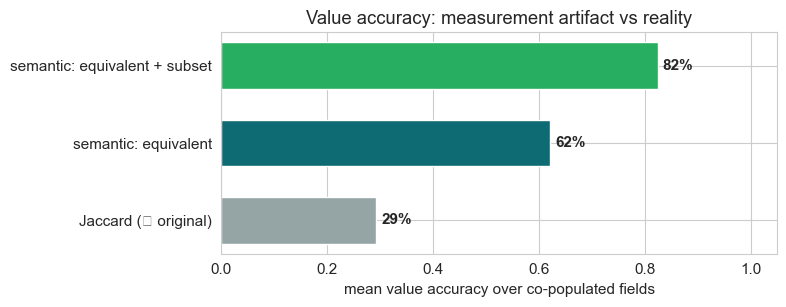

**What this shows:** the value accuracy jumps from **29%** (Jaccard) to **62%** equivalent and **82%** equivalent-or-subset. Most of the apparent failure was Jaccard penalising correct values for wording — the models are coding the *right* values far more often than the set-overlap number implied.

## 3. Which fields were artifacts, which are real errors

Per field, two things at once. **Position:** Jaccard (x) vs semantic accuracy (y) — points high above the diagonal are pure **normalization** wins (right value, Jaccard undercounted). **Colour:** the genuine-error rate (share ruled *different*) — a red point is a real coding disagreement that normalization will *not* fix, wherever it sits. A pale point high on the diagonal is the ideal (right, just needs canonicalising); a red point is a noisy clustering covariate.

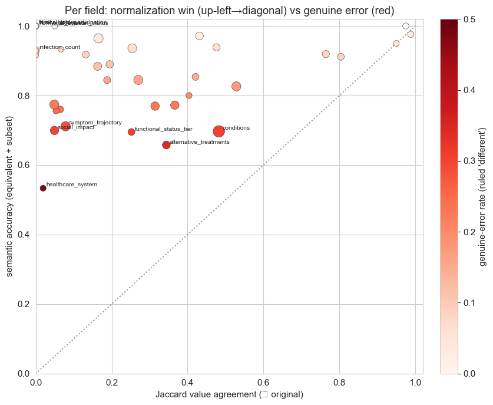

**Per-field, sorted by genuine-error rate (worst first)**

| field | Jaccard | semantic (equiv) | semantic (+subset) | genuinely different | Jaccard→sem jump | n |
| --- | --- | --- | --- | --- | --- | --- |
| healthcare_system | 2% | 53% | 53% | 47% | 51% | 30 |
| alternative_treatments | 34% | 46% | 66% | 34% | 31% | 149 |
| functional_status_tier | 25% | 37% | 70% | 30% | 44% | 82 |
| conditions | 48% | 47% | 70% | 30% | 21% | 462 |
| social_impact | 5% | 54% | 70% | 30% | 65% | 193 |
| symptom_trajectory | 8% | 48% | 71% | 29% | 63% | 260 |
| healthcare_costs | 5% | 68% | 76% | 24% | 70% | 41 |
| diagnostic_odyssey | 6% | 53% | 76% | 24% | 70% | 75 |
| mental_health | 31% | 57% | 77% | 23% | 46% | 191 |
| activity_level | 37% | 50% | 77% | 23% | 41% | 189 |
| treatment_outcome | 5% | 42% | 77% | 23% | 73% | 239 |
| dosage | 40% | 80% | 80% | 20% | 40% | 35 |
| medications | 53% | 55% | 83% | 17% | 30% | 242 |
| doctor_dismissal | 19% | 67% | 84% | 16% | 66% | 90 |
| symptom_duration | 27% | 75% | 84% | 16% | 57% | 245 |
| diagnosis_source | 42% | 72% | 85% | 15% | 43% | 82 |
| biomarker_results | 16% | 63% | 88% | 12% | 72% | 164 |
| work_disability_status | 19% | 71% | 89% | 11% | 69% | 118 |
| sex_gender | 80% | 91% | 91% | 9% | 11% | 79 |
| misdiagnosis | 0% | 42% | 92% | 8% | 92% | 24 |
| dietary_interventions | 13% | 71% | 92% | 8% | 79% | 73 |
| location_country | 76% | 83% | 92% | 8% | 15% | 99 |
| time_to_diagnosis | 0% | 86% | 93% | 7% | 93% | 28 |
| infection_count | 0% | 75% | 93% | 7% | 93% | 100 |
| covid_wave | 7% | 93% | 93% | 7% | 87% | 15 |
| prior_infections | 25% | 58% | 94% | 6% | 68% | 219 |
| long_covid_duration_months | 48% | 80% | 94% | 6% | 46% | 98 |
| age_at_onset | 95% | 95% | 95% | 5% | 0% | 20 |
| onset_trigger | 17% | 86% | 96% | 4% | 80% | 254 |
| procedures | 43% | 62% | 97% | 3% | 54% | 141 |
| age | 99% | 98% | 98% | 2% | -1% | 42 |
| clinical_trial_participation | 0% | 90% | 100% | 0% | 100% | 63 |
| hormonal_events | 0% | 100% | 100% | 0% | 100% | 20 |
| family_history | 0% | 87% | 100% | 0% | 100% | 15 |
| location_us_state | 98% | 100% | 100% | 0% | 3% | 40 |
| vaccination_status | 5% | 100% | 100% | 0% | 95% | 20 |

## 4. What the errors actually are

The three-way verdict split says how the co-populated values fail: equivalent (fine), a correct but less-complete subset (a recall/granularity gap, not a wrong value), or genuinely different (the real coding error).

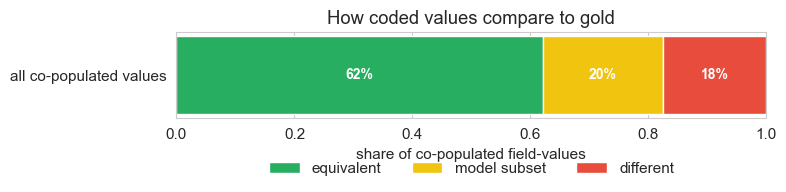

**What this shows:** only **18%** of co-populated values are genuinely wrong. **62%** mean exactly the same as gold, and **20%** are correct but less complete than Opus (a granularity gap on list fields, not a wrong value). The real coding-error rate is far below what Jaccard implied — the dominant issue is phrasing/normalization, not accuracy.

## 5. Conclusion — a two-tier fix, and a bad-covariate watchlist

The re-score settles the earlier question, but splits it in two: a normalizable majority and a genuinely error-prone interpretive tail.

**Per-model value accuracy: Jaccard vs semantic**

| model | Jaccard | semantic equiv | semantic +subset | n values |
| --- | --- | --- | --- | --- |
| grok-4.5 | 34% | 67% | 90% | 195 |
| gpt-5.6-luna | 17% | 71% | 89% | 191 |
| gpt-5.1 | 25% | 74% | 88% | 215 |
| claude-sonnet-4.6 | 28% | 73% | 87% | 219 |
| gemini-3.5-flash | 34% | 60% | 86% | 201 |
| grok-4.20 | 32% | 64% | 84% | 199 |
| gpt-5.4-nano | 15% | 72% | 84% | 198 |
| gpt-5-mini | 25% | 67% | 84% | 178 |
| deepseek-v4-flash | 28% | 63% | 83% | 176 |
| llama-4-maverick | 33% | 50% | 83% | 210 |
| claude-haiku-4.5 | 28% | 70% | 83% | 215 |
| gemini-3.1-flash-lite | 35% | 51% | 83% | 196 |
| glm-5.2 | 38% | 64% | 82% | 199 |
| gpt-5.4-mini | 30% | 70% | 82% | 221 |
| gemini-3.1-pro-preview | 34% | 62% | 82% | 213 |
| deepseek-v4-pro | 28% | 61% | 82% | 154 |
| mistral-small-2603 | 31% | 56% | 78% | 201 |
| qwen3-max | 28% | 59% | 78% | 197 |
| mistral-large-2512 | 33% | 59% | 77% | 219 |
| qwen3-30b-a3b | 26% | 45% | 75% | 183 |
| glm-4.7-flash | 30% | 51% | 75% | 75 |
| llama-4-scout | 31% | 43% | 73% | 182 |

Verdict

- **The scalar-field panic was a measurement artifact.** Semantically, values are **62%** equivalent to gold and **82%** equivalent-or-subset — vs 29% by Jaccard. Numeric/date/count fields that scored ~0 on Jaccard for phrasing ('2' vs 'at least 2') are actually right; normalization alone fixes them.

- **But the ~18% genuine-error rate is real and concentrated, not noise.** 6 interpretive free-text fields are ruled *different* ≥25% of the time: `healthcare_system` (47%), `alternative_treatments` (34%), `functional_status_tier` (30%), `conditions` (30%), `social_impact` (30%), `symptom_trajectory` (29%). These are the covariates where models genuinely disagree with Opus on **content** — normalization will not help.

- **The fix is two-tier, not one.** (1) **Normalize** the 30+ scalar/categorical fields that jump from low Jaccard to high semantic — this is judgement ③ extended to Track-B values, plus a semantic (not set-overlap) metric going forward. (2) **Harden the interpretive fields** — tighter schema/enums, or a judge panel to decide whether the disagreement is model-error or Opus over-interpretation (the ⑩ single-Opus-truth caveat bites hardest exactly here).

- **For the clustering study:** the interpretive tail above is a *bad-covariate watchlist*. Cluster on the normalizable majority with confidence; stratify, down-weight, or exclude the red fields until a panel resolves whether their disagreement is real.

## 6. Research limitations

- **Opus judges its own gold.** Opus coded the reference values and now rules on equivalence to them — mild circularity (verification ≠ generation, and "is 2 the same as at least 2" is fairly objective, but a second independent judge or a panel would tighten it). This is the same Opus-as-truth caveat flagged for ⑩.
- **"model_subset" credits incomplete lists as not-wrong** — correct for value accuracy, but a list field that systematically under-lists is still lossy for clustering; presence/recall (⑪) still matters alongside this.
- **Equivalence is per-value**; it does not re-check presence (whether the right fields were populated) — that is ⑪'s presence-F1, unchanged here.
- **Judged only co-populated fields** (both gold and model non-null); fields one side left null are a presence question, not a value one.
- Measures the correctness of a measurement step, not any treatment effect.

**Provenance**

| item | value |
| --- | --- |
| re-score generated (UTC) | 2026-07-18T02:56:40.664889+00:00 |
| source codings | j11_coding_runs.json |
| judge | anthropic/claude-opus-4.8 |
| candidate models | 22 |
| field-values judged | 4,237 |
| metric | semantic equivalence (equivalent \| subset \| different) |
| skill version | research-assistant v2 |

These findings reflect the correctness of a measurement pipeline and model knowledge, not population-level treatment effects. This is not medical advice.